# 07-RLM

### Determinación de Leverage Alto

El **leverage** para cada observación (i) se denota como ( h_{ii} ), y un valor de leverage se considera alto si cumple la siguiente condición:

$$ h_{ii} > \frac{2p}{n} $$

donde:

- ( p ) es el número de parámetros en el modelo, incluyendo el intercepto,
- ( n ) es el número total de observaciones en el conjunto de datos.

**Interpretación**: Si el leverage de una observación excede el valor de ( \frac{2p}{n} ), esta observación se considera un punto de leverage alto y puede tener una influencia considerable en el ajuste del modelo. Es recomendable analizar estos puntos de manera más profunda, ya que podrían ser outliers o representar datos atípicos en el espacio de los predictores.

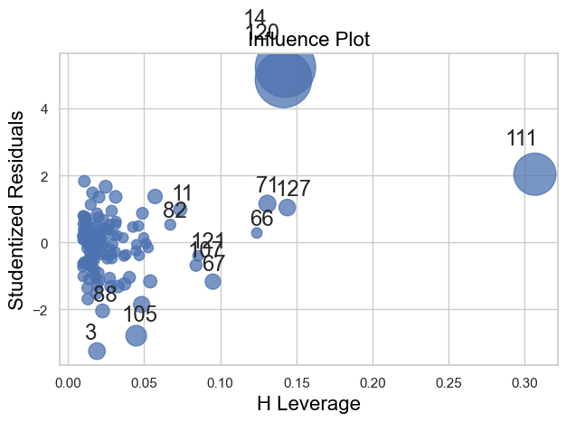

```python
fig = sm.graphics.influence_plot(model3, criterion="cooks")
fig.tight_layout(pad=1.0)
fig.show()
```

```python
# Calcula las influencias del modelo
influence = model3.get_influence()

# Obtiene el valor de Cook's distance
cooks_d = influence.cooks_distance[0]

# Establece un umbral para identificar puntos de influencia (por ejemplo, 4/n)
threshold = 4 / len(data2010)

# Identifica las observaciones que son puntos de influencia
influential_points = X[cooks_d > threshold]

# Imprime las observaciones que son puntos de influencia
print("Observaciones que son puntos de influencia:")
print(influential_points)
```

```
Observaciones que son puntos de influencia:
     const  Income composition of resources   HIV/AIDS
0      1.0                            0.448        0.1
3      1.0                            0.488        2.5
14     1.0                            0.000        0.5
67     1.0                            0.403        1.8
71     1.0                            0.430       13.7
105    1.0                            0.384        1.6
111    1.0                            0.523       21.6
120    1.0                            0.000        0.1
127    1.0                            0.436       15.7
```

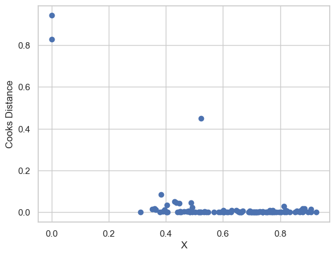

```python
plt.scatter(X["Income composition of resources"],cooks_d)
plt.xlabel("X")
plt.ylabel("Cooks Distance")
plt.show()
```

### D de Cook

La **D de Cook** es una medida en regresión lineal que identifica observaciones con un impacto desproporcionado en el ajuste del modelo. Cuanto mayor sea el valor de D de Cook para una observación, mayor es su influencia sobre los coeficientes del modelo.

#### Valor Crítico

Una observación se considera influyente si su **D de Cook es mayor a ( 4/n )**, donde ( n ) es el número total de observaciones.

```python
### Eliminando outliers
```

```python
# Elimina las observaciones con índices 111, 120 y 14 de X y y
X_filtered = X.drop([111, 120, 14])
y_filtered = y.drop([111, 120, 14])

# Ajusta el modelo nuevamente
model_filtered = sm.OLS(y_filtered, sm.add_constant(X_filtered)).fit()

# Muestra el resumen del modelo ajustado
print(model_filtered.summary())
```

```
                            OLS Regression Results
==============================================================================
Dep. Variable:       Life expectancy    R-squared:                       0.862
Model:                            OLS   Adj. R-squared:                  0.860
Method:                 Least Squares   F-statistic:                     381.2
Date:                Mon, 28 Oct 2024   Prob (F-statistic):           3.33e-53
Time:                        18:44:25   Log-Likelihood:                -325.04
No. Observations:                 125   AIC:                             656.1
Df Residuals:                     122   BIC:                             664.6
Df Model:                           2
Covariance Type:            nonrobust
===================================================================================================
                                      coef    std err          t      P>|t|      [0.025      0.975]
---------------------------------------------------------------------------------------------------
const                              43.0454      1.495     28.784      0.000      40.085      46.006
Income composition of resources    42.5752      2.145     19.851      0.000      38.330      46.821
 HIV/AIDS                          -0.8781      0.114     -7.724      0.000      -1.103      -0.653
==============================================================================
Omnibus:                       13.566   Durbin-Watson:                   2.218
Prob(Omnibus):                  0.001   Jarque-Bera (JB):               16.963
Skew:                          -0.629   Prob(JB):                     0.000207
Kurtosis:                       4.293   Cond. No.                         29.1
==============================================================================

Notes:
[1] Standard Errors assume that the covariance matrix of the errors is correctly specified.
```